# Red Wine Quality Analysis by Anshul Sharma

# Bivariate Analysis

### Talk about some of the relationships you observed in this part of the \

investigation. How did the feature(s) of interest vary with other features in \ the dataset?

Since, I'm trying to find which chemical properties of red wine affect it's quality, i studied the variations of all the 11 chemical properties with respect to the quality of the wine(10 being the highest quality and 0 being the lowest quality). I used boxplots to study the variations as the chemical properties are quantitave variables and the quality of red wine is a qualitative variable.

**Fixed acidity** and **residual sugar** did not show any sort of relation with the quality of red wine. **Volatile acidity, Chlorides & Density** showed a negative relationship i.e the values of these properties reduce with better red wine quality. **Citric Acid, Sulphates and Alcohol** showed a positive relationship i.e the values of these properties increase with better red wine quality. **Free sulfur dioxide & Total sulfur dioxide** show an interesting relationship: the values increase with quality 3 - 5 and then reduce with quality 5 - 8.

### Did you observe any interesting relationships between the other features \

(not the main feature(s) of interest)?

Apart from studying the variation of chemical properties with wine quality, I studied the the relationships between some of the chemical properties.As expected I found a negative linear relationship between the volatile acidity and citric acid. This relation was really intuitive as more fresh or flavorsome the wine the better it's quality and more unpleasant the taste of the wine the worse it's quality.

### What was the strongest relationship you found?

The strongest relationships that i found are the positive reationship between citric acid and quality and the negative relationship between volatile acidity and quality of the red wine.

# Multivariate Plots Section

Let's try and draw some scatterplots where the points will be coloured on the basis of wine quality.

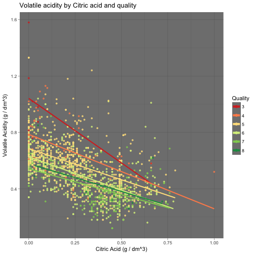

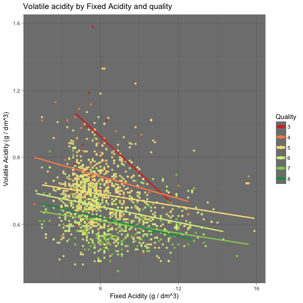

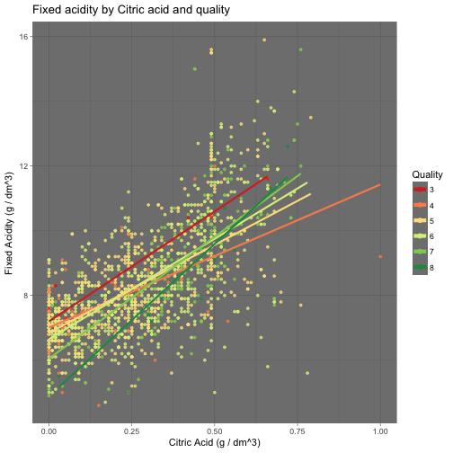

In the above plots, I'm examining the multivariate relation between volatile acidity, fixed acidity, citric acidity and quality. I had to plot 3 graphs for the 3 quantitative variables and i have added quantity as color parameter in the aesthetic wrapper to show the relations between 2 quantitative variable by quality.

The patterns observed in the above plots are in line with the observations made in the bivariate plots section baring some points in the plots where some discrepancy can be seen.

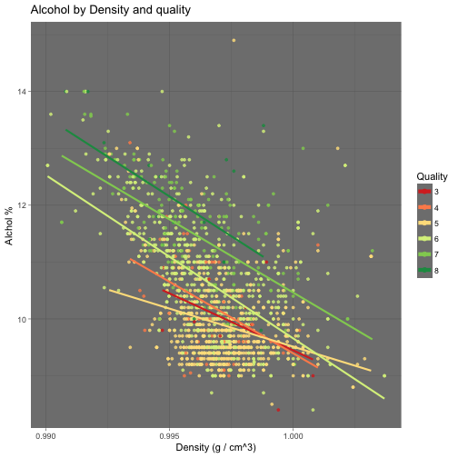

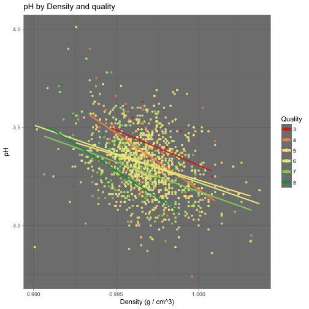

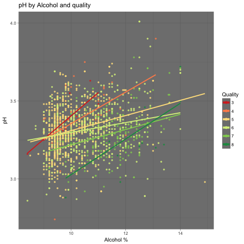

Again in the above plots, I'm examining the multivariate relation between density, alcohol, pH and quality. I had to plot 3 graphs for the 3 quantitative variables and i have added quantity as color parameter in the aesthetic wrapper to show the relations between 2 quantitative variable by quality.

The patterns observed in the above plots are in line with the observations made in the bivariate plots section baring some points in the plots where some discrepancy can be seen.

> Model

Using all the chemical properties will make a huge model and will not be easy to interpret. So, i'm using the properties that i found to affect the quality the most.

[output not shown]

[output not shown]

[output not shown]

[output not shown]

[output not shown]

# Multivariate Analysis

### Talk about some of the relationships you observed in this part of the \

investigation. Were there features that strengthened each other in terms of \ looking at your feature(s) of interest?

### Were there any interesting or surprising interactions between features?

Yes, volatile acidity by citric acidity and quality is the most interesting relationship. As stated in the above sections, volatile acidity is the amount of acetic which can lead to unpleasant vinegar like taste and citric acid on the other hand adds freshness to the wine and hence, makes it more flavorsome. So, ideally the wine quality should improve with increase in citric acid content and worsen with increase in volatile acidity. Also, there should be a negative relation between citric acid and volatile acidity. Interestingly, on creating the plot I found that my perceptions were right.

### OPTIONAL: Did you create any models with your dataset? Discuss the \

strengths and limitations of your model.

Since, quality is a categorical variable with 6 distinct levels, I had to use mulinomial logistic linear regression. There are about 11 chemical properties and including all of them into the mathematical model would have complicated it. So, i took all the properties that i found useful throughout my analysis. The limitation with this model is that the result will not be much accurate as none of the properties are strongly correlated with quality.

# Final Plots and Summary

### Plot One

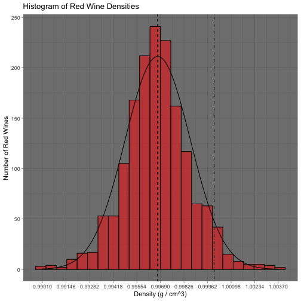

### Description One

The above shows the histogram of wine densities in g / cm<sup>3.</sup> It's mean and median values overlap each other and has an almost perfectly normal distribution The other dotted line with x-intercept 1 g / cm<sup>3</sup> depicts the density of water and a minority of red wines are dense than water.

### Plot Two

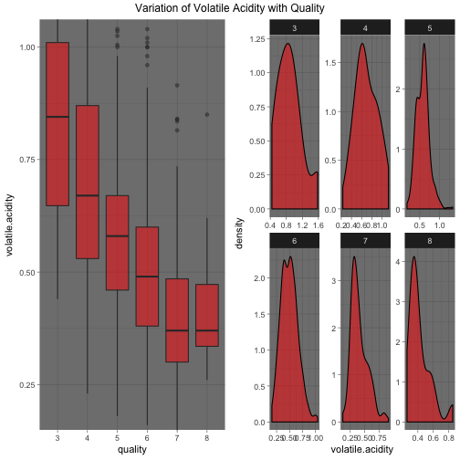

### Description Two

In the above plots the variation of volatile acidity is shown with quality of red wine. The first plot shows the boxplots of volatile acidity for each quality of red wine while the second plot shows the density plots(smoothed histograms) of volatile acidity faceted by wine quality. From the plots it can be inferred that quality of red wine improves as its volatile acidity decreases. The faceted density plots appear to be right skewed.

### Plot Three

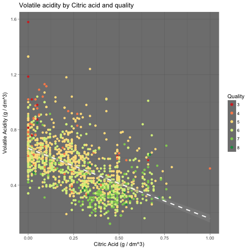

### Description Three

The above plot shows an interesting multivariate relationship between volatile acidity, citric acid and quality of a red wine. The white dotted line denotes the linear model on which the predicted values lie. There can be seen a negative linear relationship between volatile acidity and citric acid. The variation of both the properties with quality can also be proved by examining the plot.

# Reflection

There was a clear trend between volatile acidity, citric acid, chloride, density , pH, suphates or alcohol content of a red wine and its quality. I was surprised that residual sugar or fixed acidity did not have any sort of correlation with price. I struggled understanding the strange relationship between quality and free sulfur dioxide & total sulfur dioxide: they increase with quality 3 - 5 and then decrease with quality 5 - 8 red wine. For the linear model, all red wines were included since information on all the variables was available for all the red wines. Since, quality of red wine is a categorical variable with 6 distinct levels, I used multinomial logistics regression for creating the mathematical model.

Some limitations of this model include the data bias. By data bias, i mean that the majority of red wines were in the quality range 5-7 and the rest were very less in numbers. If price of red wines is also included in the dataset, I would be interested in testing the linear model to predict red wines prices and to determine to what extent the model is accurate at pricing red wines.